# Heart_Attack_Risk_Predictor with Eval ML

#### Let us build a proper confusion matrix for our model

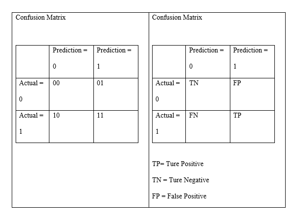

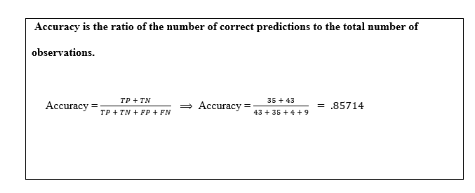

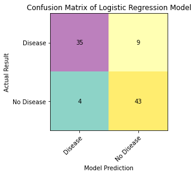

```
ACCURACY of our model is  85.71428571428571 %
```

```python
# Confusion Matrix of  Model enlarged
options = ["Disease", 'No Disease']

fig, ax = plt.subplots()
im = ax.imshow(lr_conf_matrix, cmap= 'Set3', interpolation='nearest')

# We want to show all ticks...
ax.set_xticks(np.arange(len(options)))
ax.set_yticks(np.arange(len(options)))
# ... and label them with the respective list entries
ax.set_xticklabels(options)
ax.set_yticklabels(options)

# Rotate the tick labels and set their alignment.
plt.setp(ax.get_xticklabels(), rotation=45, ha="right",
         rotation_mode="anchor")

# Loop over data dimensions and create text annotations.
for i in range(len(options)):
    for j in range(len(options)):
        text = ax.text(j, i, lr_conf_matrix[i, j],
                       ha="center", va="center", color="black")

ax.set_title("Confusion Matrix of Logistic Regression Model")
fig.tight_layout()
plt.xlabel('Model Prediction')
plt.ylabel('Actual Result')
plt.show()
print("ACCURACY of our model is ",lr_acc_score*100,"%")
```

Once again, a logistic regression model's goal is to predict whether the binary response Y takes on a value of 0 or 1. We can see that our accuracy is 85.714 percent, which is close to 1. Accuracy is the ratio of the number of correct predictions to the total number of observations. When assessing the classification model's performance, our accuracy is near one, which is extremely well, which means that. Our model is doing a good job in distinguishing what is in a binary value, said what is a 0 and what is a 1. Then we should expect good results are moving forward.

## We have succesfully made our model which predicts weather a person is having a risk of Heart Disease or not with 85.7% accuracy

The general form of a logistic regression model for as independent variables are Age, Sex, Exang, Ca, Cp, Trtbps, Chol, Fbs, Rest_ecg, Thalach . Independent variable which is the Target predicts weather a person is having a risk of heart disease not and our accuracy is 85.7 perceent Though, I think more variables need to be analyzed and evaluated to find which variable will produce the highest probability of finding the regression model that best fits the situation. The whole objective is to develop a regression model that is custom to the scenario. The key is to understand when a data set has and what type of regression model to use.

```python
import pickle
```

```python
pickle.dump(logreg,open('heart.pkl','wb'))
```

# EVAL ML :

[figure not shown]

### EvalML is an open-source AutoML library written in python that automates a large part of the machine learning process and we can easily evaluate which machine learning pipeline works better for the given set of data.

AutoML is the process of automating the construction, training and evaluation of ML models. Given a data and some configuration, AutoML searches for the most effective and accurate ML model or models to fit the dataset. During the search, AutoML will explore different combinations of model type, model parameters and model architecture. We used to further evaluate our data set and compare to are logistic regression model.

## Installing Eval ML

```python
!pip install evalml
```

[output not shown]

[output cut: 67 more lines]

[output not shown]

# Let us load our DataSet.

```python
df= pd.read_csv("heart.csv")
```

```python
df.head()
```

|  | age | sex | cp | trtbps | chol | fbs | restecg | thalachh | exng | oldpeak | slp | caa | thall | output |
| --- | --- | --- | --- | --- | --- | --- | --- | --- | --- | --- | --- | --- | --- | --- |
| 0 | 63 | 1 | 3 | 145 | 233 | 1 | 0 | 150 | 0 | 2.3 | 0 | 0 | 1 | 1 |
| 1 | 37 | 1 | 2 | 130 | 250 | 0 | 1 | 187 | 0 | 3.5 | 0 | 0 | 2 | 1 |
| 2 | 41 | 0 | 1 | 130 | 204 | 0 | 0 | 172 | 0 | 1.4 | 2 | 0 | 2 | 1 |
| 3 | 56 | 1 | 1 | 120 | 236 | 0 | 1 | 178 | 0 | 0.8 | 2 | 0 | 2 | 1 |
| 4 | 57 | 0 | 0 | 120 | 354 | 0 | 1 | 163 | 1 | 0.6 | 2 | 0 | 2 | 1 |

Let us split our Data Set into Dependent i.e our Targer variable and independent variable

```python
x= df.iloc[:,:-1]
x
```

[output not shown]

```python
y= df.iloc[:,-1:]
y= lbl.fit_transform(y)
y
```

```
array([1, 1, 1, 1, 1, 1, 1, 1, 1, 1, 1, 1, 1, 1, 1, 1, 1, 1, 1, 1, 1, 1,
       1, 1, 1, 1, 1, 1, 1, 1, 1, 1, 1, 1, 1, 1, 1, 1, 1, 1, 1, 1, 1, 1,
       1, 1, 1, 1, 1, 1, 1, 1, 1, 1, 1, 1, 1, 1, 1, 1, 1, 1, 1, 1, 1, 1,
       1, 1, 1, 1, 1, 1, 1, 1, 1, 1, 1, 1, 1, 1, 1, 1, 1, 1, 1, 1, 1, 1,
       1, 1, 1, 1, 1, 1, 1, 1, 1, 1, 1, 1, 1, 1, 1, 1, 1, 1, 1, 1, 1, 1,
       1, 1, 1, 1, 1, 1, 1, 1, 1, 1, 1, 1, 1, 1, 1, 1, 1, 1, 1, 1, 1, 1,
       1, 1, 1, 1, 1, 1, 1, 1, 1, 1, 1, 1, 1, 1, 1, 1, 1, 1, 1, 1, 1, 1,
       1, 1, 1, 1, 1, 1, 1, 1, 1, 1, 1, 0, 0, 0, 0, 0, 0, 0, 0, 0, 0, 0,
       0, 0, 0, 0, 0, 0, 0, 0, 0, 0, 0, 0, 0, 0, 0, 0, 0, 0, 0, 0, 0, 0,
       0, 0, 0, 0, 0, 0, 0, 0, 0, 0, 0, 0, 0, 0, 0, 0, 0, 0, 0, 0, 0, 0,
       0, 0, 0, 0, 0, 0, 0, 0, 0, 0, 0, 0, 0, 0, 0, 0, 0, 0, 0, 0, 0, 0,
       0, 0, 0, 0, 0, 0, 0, 0, 0, 0, 0, 0, 0, 0, 0, 0, 0, 0, 0, 0, 0, 0,
       0, 0, 0, 0, 0, 0, 0, 0, 0, 0, 0, 0, 0, 0, 0, 0, 0, 0, 0, 0, 0, 0,
       0, 0, 0, 0, 0, 0, 0, 0, 0, 0, 0, 0, 0, 0, 0, 0, 0])
```

# **Importing Eval ML Library**

```python
import evalml
```

Eval ML Library will do all the pre processing techniques for us and split the data for us. The proportionate use is 80 percent for training data and 20 percent for test data.

```python
X_train, X_test, y_train, y_test = evalml.preprocessing.split_data(x, y, problem_type='binary')
```

There are different problem type parameters in Eval ML, we have a Binary type problem here, that's why we are using Binary as a input

```python
evalml.problem_types.ProblemTypes.all_problem_types
```

```
[<ProblemTypes.BINARY: 'binary'>,
 <ProblemTypes.MULTICLASS: 'multiclass'>,
 <ProblemTypes.REGRESSION: 'regression'>,
 <ProblemTypes.TIME_SERIES_REGRESSION: 'time series regression'>,
 <ProblemTypes.TIME_SERIES_BINARY: 'time series binary'>,
 <ProblemTypes.TIME_SERIES_MULTICLASS: 'time series multiclass'>]
```

**Running the Auto ML to select best Algorithm** BINARY, MULTICLASS:, REGRESSION, TIME_SERIES_REGRESSION, TIME_SERIES_BINARY and TIME_SERIES_MULTICLASS are different multi classes and we use binary.

AutoML is the process of automating the construction, training and evaluation of ML models. Given a data and some configuration, AutoML searches for the most effective and accurate ML model or models to fit the dataset. During the search, AutoML will explore different combinations of model type, model parameters and model architecture.

```python
from evalml.automl import AutoMLSearch
automl = AutoMLSearch(X_train=X_train, y_train=y_train, problem_type='binary')
automl.search()
```

```
Using default limit of max_batches=1.

Generating pipelines to search over...
8 pipelines ready for search.

* Beginning pipeline search *

Optimizing for Log Loss Binary.
Lower score is better.

Using SequentialEngine to train and score pipelines.
Searching up to 1 batches for a total of 9 pipelines.
Allowed model families: random_forest, extra_trees, decision_tree, lightgbm, linear_model, catboost, xgboost
```

```
Evaluating Baseline Pipeline: Mode Baseline Binary Classification Pipeline
Mode Baseline Binary Classification Pipeline:
	Starting cross validation
	Finished cross validation - mean Log Loss Binary: 15.699

* Evaluating Batch Number 1 *

Elastic Net Classifier w/ Imputer + Standard Scaler:
	Starting cross validation
	Finished cross validation - mean Log Loss Binary: 0.488
Decision Tree Classifier w/ Imputer:
	Starting cross validation
	Finished cross validation - mean Log Loss Binary: 7.031
Random Forest Classifier w/ Imputer:
	Starting cross validation
	Finished cross validation - mean Log Loss Binary: 0.452
LightGBM Classifier w/ Imputer:
	Starting cross validation
	Finished cross validation - mean Log Loss Binary: 0.517
Logistic Regression Classifier w/ Imputer + Standard Scaler:
	Starting cross validation
	Finished cross validation - mean Log Loss Binary: 0.488
```

[output not shown]

[output not shown]

```
[08:58:55] WARNING: ../src/learner.cc:1095: Starting in XGBoost 1.3.0, the default evaluation metric used with the objective 'binary:logistic' was changed from 'error' to 'logloss'. Explicitly set eval_metric if you'd like to restore the old behavior.
XGBoost Classifier w/ Imputer:
	Starting cross validation
	Finished cross validation - mean Log Loss Binary: 0.534
Extra Trees Classifier w/ Imputer:
	Starting cross validation
	Finished cross validation - mean Log Loss Binary: 0.442
CatBoost Classifier w/ Imputer:
	Starting cross validation
	Finished cross validation - mean Log Loss Binary: 0.656

Search finished after 00:15
Best pipeline: Extra Trees Classifier w/ Imputer
Best pipeline Log Loss Binary: 0.441986
```

As we see from the above output thge Auto ML Classifier has given us the best fit Algorithm which is Extra Trees Classifier with Imputer We can also commpare the rest of the models

```python
automl.rankings
```

|  | id | pipeline_name | search_order | mean_cv_score | standard_deviation_cv_score | validation_score | percent_better_than_baseline | high_variance_cv | parameters |
| --- | --- | --- | --- | --- | --- | --- | --- | --- | --- |
| 0 | 7 | Extra Trees Classifier w/ Imputer | 7 | 0.441986 | 0.025672 | 0.456773 | 97.184590 | False | {'Imputer': {'categorical_impute_strategy': 'm... |
| 1 | 3 | Random Forest Classifier w/ Imputer | 3 | 0.451508 | 0.021426 | 0.466939 | 97.123934 | False | {'Imputer': {'categorical_impute_strategy': 'm... |
| 2 | 5 | Logistic Regression Classifier w/ Imputer + St... | 5 | 0.488080 | 0.031375 | 0.520345 | 96.890973 | False | {'Imputer': {'categorical_impute_strategy': 'm... |
| 3 | 1 | Elastic Net Classifier w/ Imputer + Standard S... | 1 | 0.488306 | 0.030127 | 0.519350 | 96.889536 | False | {'Imputer': {'categorical_impute_strategy': 'm... |
| 4 | 4 | LightGBM Classifier w/ Imputer | 4 | 0.517282 | 0.019277 | 0.539132 | 96.704958 | False | {'Imputer': {'categorical_impute_strategy': 'm... |
| 5 | 6 | XGBoost Classifier w/ Imputer | 6 | 0.534406 | 0.052329 | 0.592613 | 96.595882 | False | {'Imputer': {'categorical_impute_strategy': 'm... |
| 6 | 8 | CatBoost Classifier w/ Imputer | 8 | 0.655683 | 0.002337 | 0.654572 | 95.823353 | False | {'Imputer': {'categorical_impute_strategy': 'm... |
| 7 | 2 | Decision Tree Classifier w/ Imputer | 2 | 7.031453 | 0.909063 | 6.980170 | 55.210248 | False | {'Imputer': {'categorical_impute_strategy': 'm... |
| 8 | 0 | Mode Baseline Binary Classification Pipeline | 0 | 15.698798 | 0.135402 | 15.776972 | 0.000000 | False | {'Baseline Classifier': {'strategy': 'mode'}} |

```python
automl.best_pipeline
```

```
pipeline = BinaryClassificationPipeline(component_graph={'Imputer': ['Imputer', 'X', 'y'], 'Extra Trees Classifier': ['Extra Trees Classifier', 'Imputer.x', 'y']}, parameters={'Imputer':{'categorical_impute_strategy': 'most_frequent', 'numeric_impute_strategy': 'mean', 'categorical_fill_value': None…
```

```python
best_pipeline=automl.best_pipeline
```

We can have a Detailed description of our Best Selected Model

```python
automl.describe_pipeline(automl.rankings.iloc[0]["id"])
```

```
* Extra Trees Classifier w/ Imputer *

Problem Type: binary
Model Family: Extra Trees

Pipeline Steps
==============
1. Imputer
	 * categorical_impute_strategy : most_frequent
	 * numeric_impute_strategy : mean
	 * categorical_fill_value : None
	 * numeric_fill_value : None
2. Extra Trees Classifier
	 * n_estimators : 100
	 * max_features : auto
	 * max_depth : 6
	 * min_samples_split : 2
	 * min_weight_fraction_leaf : 0.0
	 * n_jobs : -1

Training
========
Training for binary problems.
Total training time (including CV): 2.1 seconds

Cross Validation
----------------
             Log Loss Binary  MCC Binary  Gini   AUC  Precision    F1  Balanced Accuracy Binary  Accuracy Binary # Training # Validation
0                      0.457       0.584 0.785 0.893      0.857 0.738                     0.779            0.790        161           81
1                      0.412       0.676 0.806 0.903      0.833 0.822                     0.837            0.840        161           81
2                      0.457       0.591 0.732 0.866      0.913 0.712                     0.769            0.787        162           80
mean                   0.442       0.617 0.774 0.887      0.868 0.757                     0.795            0.806          -            -
std                    0.026       0.051 0.038 0.019      0.041 0.057                     0.037            0.029          -            -
coef of var            0.058       0.083 0.049 0.021      0.047 0.076                     0.046            0.036          -            -
```

```python
best_pipeline.score(X_test, y_test, objectives=["auc","f1","Precision","Recall"])
```

```
OrderedDict([('AUC', 0.8852813852813852),
             ('F1', 0.7812499999999999),
             ('Precision', 0.8064516129032258),
             ('Recall', 0.7575757575757576)])
```

Now if we want to build our Model for a specific objective we can do that

```python
automl_auc = AutoMLSearch(X_train=X_train, y_train=y_train,
                          problem_type='binary',
                          objective='auc',
                          additional_objectives=['f1', 'precision'],
                          max_batches=1,
                          optimize_thresholds=True)

automl_auc.search()
```

```
Generating pipelines to search over...
8 pipelines ready for search.

* Beginning pipeline search *

Optimizing for AUC.
Greater score is better.

Using SequentialEngine to train and score pipelines.
Searching up to 1 batches for a total of 9 pipelines.
Allowed model families: random_forest, extra_trees, decision_tree, lightgbm, linear_model, catboost, xgboost
```

```
Evaluating Baseline Pipeline: Mode Baseline Binary Classification Pipeline
Mode Baseline Binary Classification Pipeline:
	Starting cross validation
	Finished cross validation - mean AUC: 0.500

* Evaluating Batch Number 1 *

Elastic Net Classifier w/ Imputer + Standard Scaler:
	Starting cross validation
	Finished cross validation - mean AUC: 0.847
Decision Tree Classifier w/ Imputer:
	Starting cross validation
	Finished cross validation - mean AUC: 0.723
Random Forest Classifier w/ Imputer:
	Starting cross validation
	Finished cross validation - mean AUC: 0.874
LightGBM Classifier w/ Imputer:
	Starting cross validation
	Finished cross validation - mean AUC: 0.843
Logistic Regression Classifier w/ Imputer + Standard Scaler:
	Starting cross validation
	Finished cross validation - mean AUC: 0.848
```

[output not shown]

```
[09:05:38] WARNING: ../src/learner.cc:1095: Starting in XGBoost 1.3.0, the default evaluation metric used with the objective 'binary:logistic' was changed from 'error' to 'logloss'. Explicitly set eval_metric if you'd like to restore the old behavior.
[09:05:39] WARNING: ../src/learner.cc:1095: Starting in XGBoost 1.3.0, the default evaluation metric used with the objective 'binary:logistic' was changed from 'error' to 'logloss'. Explicitly set eval_metric if you'd like to restore the old behavior.
XGBoost Classifier w/ Imputer:
	Starting cross validation
	Finished cross validation - mean AUC: 0.849
```

```
Extra Trees Classifier w/ Imputer:
	Starting cross validation
	Finished cross validation - mean AUC: 0.887
CatBoost Classifier w/ Imputer:
	Starting cross validation
	Finished cross validation - mean AUC: 0.822

Search finished after 00:14
Best pipeline: Extra Trees Classifier w/ Imputer
Best pipeline AUC: 0.887205
```

```python
automl_auc.rankings
```

|  | id | pipeline_name | search_order | mean_cv_score | standard_deviation_cv_score | validation_score | percent_better_than_baseline | high_variance_cv | parameters |
| --- | --- | --- | --- | --- | --- | --- | --- | --- | --- |
| 0 | 7 | Extra Trees Classifier w/ Imputer | 7 | 0.887205 | 0.018958 | 0.892506 | 38.720539 | False | {'Imputer': {'categorical_impute_strategy': 'm... |
| 1 | 3 | Random Forest Classifier w/ Imputer | 3 | 0.873658 | 0.013643 | 0.869779 | 37.365775 | False | {'Imputer': {'categorical_impute_strategy': 'm... |
| 2 | 6 | XGBoost Classifier w/ Imputer | 6 | 0.849162 | 0.027477 | 0.818182 | 34.916166 | False | {'Imputer': {'categorical_impute_strategy': 'm... |
| 3 | 5 | Logistic Regression Classifier w/ Imputer + St... | 5 | 0.848007 | 0.017890 | 0.842752 | 34.800710 | False | {'Imputer': {'categorical_impute_strategy': 'm... |
| 4 | 1 | Elastic Net Classifier w/ Imputer + Standard S... | 1 | 0.847393 | 0.016866 | 0.842752 | 34.739285 | False | {'Imputer': {'categorical_impute_strategy': 'm... |
| 5 | 4 | LightGBM Classifier w/ Imputer | 4 | 0.842994 | 0.013211 | 0.837224 | 34.299356 | False | {'Imputer': {'categorical_impute_strategy': 'm... |
| 6 | 8 | CatBoost Classifier w/ Imputer | 8 | 0.821640 | 0.023350 | 0.796069 | 32.163982 | False | {'Imputer': {'categorical_impute_strategy': 'm... |
| 7 | 2 | Decision Tree Classifier w/ Imputer | 2 | 0.722694 | 0.052690 | 0.746929 | 22.269429 | False | {'Imputer': {'categorical_impute_strategy': 'm... |
| 8 | 0 | Mode Baseline Binary Classification Pipeline | 0 | 0.500000 | 0.000000 | 0.500000 | 0.000000 | False | {'Baseline Classifier': {'strategy': 'mode'}} |

```python
automl_auc.describe_pipeline(automl_auc.rankings.iloc[0]["id"])
```

```
* Extra Trees Classifier w/ Imputer *

Problem Type: binary
Model Family: Extra Trees

Pipeline Steps
==============
1. Imputer
	 * categorical_impute_strategy : most_frequent
	 * numeric_impute_strategy : mean
	 * categorical_fill_value : None
	 * numeric_fill_value : None
2. Extra Trees Classifier
	 * n_estimators : 100
	 * max_features : auto
	 * max_depth : 6
	 * min_samples_split : 2
	 * min_weight_fraction_leaf : 0.0
	 * n_jobs : -1

Training
========
Training for binary problems.
Total training time (including CV): 2.1 seconds

Cross Validation
----------------
              AUC    F1  Precision # Training # Validation
0           0.893 0.738      0.857        161           81
1           0.903 0.822      0.833        161           81
2           0.866 0.712      0.913        162           80
mean        0.887 0.757      0.868          -            -
std         0.019 0.057      0.041          -            -
coef of var 0.021 0.076      0.047          -            -
```

```python
best_pipeline_auc = automl_auc.best_pipeline
```

```python
# get the score on holdout data
best_pipeline_auc.score(X_test, y_test,  objectives=["auc"])
```

```
OrderedDict([('AUC', 0.8852813852813852)])
```

Save the model

```python
best_pipeline.save("model.pkl")
```

Loading our Model

```python
final_model=automl.load('model.pkl')
```

```python
final_model.predict_proba(X_test)
```

|  | 0 | 1 |
| --- | --- | --- |
| 0 | 0.468324 | 0.531676 |
| 1 | 0.093848 | 0.906152 |
| 2 | 0.383646 | 0.616354 |
| 3 | 0.107272 | 0.892728 |
| 4 | 0.141027 | 0.858973 |
| ... | ... | ... |
| 56 | 0.268136 | 0.731864 |
| 57 | 0.846652 | 0.153348 |
| 58 | 0.861607 | 0.138393 |
| 59 | 0.739515 | 0.260485 |
| 60 | 0.878833 | 0.121167 |

61 rows × 2 columns

# Conclusion